# Locality weather charts for 2026

2026-09-17

## Question and definitions

Recreate the existing annual temperature-range and within-month accumulated-rain chart for the three requested localities. Final locality selection: “ok use 1. Banashankari; 2. Indiranagar; 3. Bellandur”. This is a chart prototype, not a test of whether any locality has broken a historical record.

- Unit: station-day, midnight to midnight IST. Expected denominator: 24 distinct hours for each metric. Temperature is the minimum and maximum of hourly means; rainfall is the sum of derived hourly increments, never the daily counter.
- Require 24 valid hours for the WeatherUnion daily values. For the historical Oikolab portion, follow the existing daily chart: use available temperature extrema and sum available rainfall, with absent rainfall contributing zero. Latest clarification: “no don’t keep it blank. how do we do it normally inour daily chart? use the same. if incomplete assume 0.”
- Source switch: following the latest user clarification, use Oikolab **ERA5-only** city days before 2026-03-01, and WeatherUnion only from that date onward. Earlier WeatherUnion readings are deliberately excluded from the plotted series. Leave every later station gap unfilled. Exact clarification: “Use data only from March 1st fall back to oikOLab until February.”
- Keep the last 7 completed calendar days and today unfilled. Do not replace missing recent observations, extrapolate, or use GFS.
- The user explicitly requests a composite: retain each metric’s provenance and display fallback separately. It is not a homogeneous station climate series.
- Reference: the same Oikolab city grid, 1981 through 2025, with current-year observations excluded. These are city references, not locality normals.
- Rain accumulation stops after an unresolved missing day until the next month. Mixed-source months remain visibly marked. The requested zero-rain assumption applies to the historical ERA5 portion; later WeatherUnion gaps remain unfilled.
- Stop or narrow if keys repeat, sources cannot be identified, or the requested station does not exist. Any apparent spatial difference that depends on fallback is weakened; local rankings require matched WeatherUnion days.

## First, check the station archive

```r
open_dataset(file.path(root_dir, "data/weatherunion_bengaluru_hourly.parquet")) -> archive
archive %>%
  distinct(locality_id, current_locality_name) %>%
  collect() %>%
  filter(current_locality_name %in% params$localities) -> stations
stopifnot(nrow(stations) == length(params$localities))
start_ist <- as.POSIXct(as.character(first_day), tz = "Asia/Kolkata")
end_ist <- as.POSIXct(as.character(last_complete_day + 1), tz = "Asia/Kolkata")
archive %>%
  filter(
    locality_id %in% stations$locality_id,
    hour_ist >= start_ist,
    hour_ist < end_ist
  ) %>%
  collect() %>%
  mutate(date = as.Date(hour_ist, tz = "Asia/Kolkata")) -> wu
stopifnot(!anyDuplicated(wu[c("locality_id", "hour_ist")]))
stopifnot(all(wu$rain_mm >= 0 | is.na(wu$rain_mm)))
wu %>%
  summarise(
    first = min(date),
    latest = max(date),
    observed_hours = n(),
    valid_temperature_hours = sum(is.finite(temperature_c)),
    valid_rain_hours = sum(is.finite(rain_mm)),
    .by = locality_id
  ) %>%
  left_join(stations, by = "locality_id") %>%
  mutate(expected_hours = as.integer(latest - first + 1) * 24) -> coverage
coverage
```

```
## # A tibble: 3 × 8
##   locality_id first      latest     observed_hours valid_temperature_hours
##   <chr>       <date>     <date>              <int>                   <int>
## 1 ZWL001273   2026-02-22 2026-09-15           4944                    4944
## 2 ZWL003467   2026-02-22 2026-09-15           4944                    4944
## 3 ZWL004164   2026-02-22 2026-09-15           4944                    4944
## # ℹ 3 more variables: valid_rain_hours <int>, current_locality_name <chr>,
## #   expected_hours <dbl>
```

```r
wu %>%
  summarise(
    temp_hours = sum(is.finite(temperature_c)),
    rain_hours = sum(is.finite(rain_mm)),
    low = if (temp_hours == 24) min(temperature_c) else NA_real_,
    high = if (temp_hours == 24) max(temperature_c) else NA_real_,
    rain = if (rain_hours == 24) sum(rain_mm) else NA_real_,
    .by = c(locality_id, date)
  ) -> wu_daily
wu_daily %>%
  summarise(
    days_with_rows = n(),
    full_temp_days = sum(temp_hours == 24),
    full_rain_days = sum(rain_hours == 24),
    .by = locality_id
  ) %>%
  left_join(stations, by = "locality_id")
```

```
## # A tibble: 3 × 5
##   locality_id days_with_rows full_temp_days full_rain_days current_locality_name
##   <chr>                <int>          <int>          <int> <chr>
## 1 ZWL001273              206            206            206 Indiranagar
## 2 ZWL003467              206            206            206 Banashankari
## 3 ZWL004164              206            206            206 Bellandur
```

All three selected stations have 206 complete days each, covering every hour from February 22 through September 15 for both temperature and rainfall. Hourly coverage does not guarantee all 60 minutes were sampled or certify sensor accuracy.

## Prepare the city reference separately

Use explicit IST dates for both sources. ERA5 samples are on the half-hour in IST; WeatherUnion timestamps name hourly intervals. Their daily summaries are comparable context, not identical measurement procedures.

```r
load(file.path(root_dir, "data", "bangaloreTemperature.RData"))
load(file.path(root_dir, "data", "bangaloreRainfall.RData"))
as_tibble(blrTemp) %>%
  filter(Source == "era5") %>%
  transmute(
    timestamp = DT,
    date = as.Date(DT, tz = "Asia/Kolkata"),
    temp = as.numeric(Temp)
  ) -> era_temp
as_tibble(blrRain) %>%
  filter(Source == "era5") %>%
  transmute(
    timestamp = DT,
    date = as.Date(DT, tz = "Asia/Kolkata"),
    rain = as.numeric(Rain)
  ) -> era_rain
stopifnot(!anyDuplicated(era_temp$timestamp), !anyDuplicated(era_rain$timestamp))
era_temp %>%
  summarise(
    hours = sum(is.finite(temp)),
    era_low = if (hours > 0) min(temp, na.rm = TRUE) else NA_real_,
    era_high = if (hours > 0) max(temp, na.rm = TRUE) else NA_real_,
    .by = date
  ) -> era_temp_daily
era_rain %>%
  summarise(
    hours = sum(is.finite(rain)),
    # Match the daily chart: absent rainfall contributes zero, per user instruction.
    era_rain = sum(rain, na.rm = TRUE),
    .by = date
  ) -> era_rain_daily
era_temp_daily %>%
  select(-hours) %>%
  full_join(select(era_rain_daily, -hours), by = "date") %>%
  arrange(date) %>%
  mutate(yr = year(date), month = month(date), day = day(date)) -> era_daily
era_daily %>%
  summarise(
    first_available_temp = min(date[is.finite(era_low)]),
    latest_available_temp = max(date[is.finite(era_low)]),
    latest_available_rain = max(date[is.finite(era_rain)])
  )
```

```
## # A tibble: 1 × 3
##   first_available_temp latest_available_temp latest_available_rain
##   <date>               <date>                <date>
## 1 1981-01-01           2026-09-11            2026-09-11
```

```r
era_daily %>%
  filter(yr < chart_year, is.finite(era_low), is.finite(era_high)) %>%
  summarise(
    reference_low = min(era_low),
    reference_high = max(era_high),
    normal_low = median(era_low),
    normal_high = median(era_high),
    reference_years = n(),
    .by = c(month, day)
  ) %>%
  mutate(date = make_date(chart_year, month, day)) %>%
  filter(!is.na(date)) -> temp_reference
era_daily %>%
  filter(yr < chart_year) %>%
  group_by(yr, month) %>%
  filter(n() == days_in_month(first(date)), all(is.finite(era_rain))) %>%
  arrange(date, .by_group = TRUE) %>%
  mutate(cumulative = cumsum(era_rain)) %>%
  ungroup() %>%
  summarise(
    p10 = quantile(cumulative, 0.10),
    p25 = quantile(cumulative, 0.25),
    median = median(cumulative),
    p75 = quantile(cumulative, 0.75),
    p90 = quantile(cumulative, 0.90),
    reference_years = n(),
    .by = c(month, day)
  ) %>%
  mutate(date = make_date(chart_year, month, day)) %>%
  filter(!is.na(date), date <= last_complete_day) -> rain_reference
```

## Keep the source with every value

```r
crossing(
  locality_id = stations$locality_id,
  date = seq(first_day, last_complete_day, by = "day")
) %>%
  left_join(stations, by = "locality_id") %>%
  left_join(select(coverage, locality_id, first), by = "locality_id") %>%
  left_join(wu_daily, by = c("locality_id", "date")) %>%
  left_join(select(era_daily, date, era_low, era_high, era_rain), by = "date") %>%
  mutate(
    fallback_allowed = date < recent_start & date < local_start,
    temp_source = case_when(
      date >= local_start & is.finite(low) & is.finite(high) ~ "WeatherUnion",
      fallback_allowed & is.finite(era_low) & is.finite(era_high) ~ "Oikolab fallback",
      TRUE ~ "Missing"
    ),
    rain_source = case_when(
      date >= local_start & is.finite(rain) ~ "WeatherUnion",
      fallback_allowed ~ "Oikolab fallback",
      TRUE ~ "Missing"
    ),
    low = case_when(
      temp_source == "WeatherUnion" ~ low,
      temp_source == "Oikolab fallback" ~ era_low,
      TRUE ~ NA_real_
    ),
    high = case_when(
      temp_source == "WeatherUnion" ~ high,
      temp_source == "Oikolab fallback" ~ era_high,
      TRUE ~ NA_real_
    ),
    rain = case_when(
      rain_source == "WeatherUnion" ~ rain,
      rain_source == "Oikolab fallback" ~ coalesce(era_rain, 0),
      TRUE ~ NA_real_
    ),
    month = month(date)
  ) %>%
  group_by(locality_id, month) %>%
  arrange(date, .by_group = TRUE) %>%
  mutate(
    cumulative = cumsum(rain),
    cumulative_has_fallback = cumany(rain_source == "Oikolab fallback"),
    cumulative_source = case_when(
      is.na(cumulative) ~ "Missing",
      cumulative_has_fallback ~ "Includes Oikolab fallback",
      TRUE ~ "WeatherUnion"
    )
  ) %>%
  ungroup() -> daily
# These are data-integrity checks on the actual analysis, not a test suite.
stopifnot(!anyDuplicated(daily[c("locality_id", "date")]))
stopifnot(!any(daily$temp_source == "Oikolab fallback" & daily$date >= recent_start))
stopifnot(!any(daily$rain_source == "Oikolab fallback" & daily$date >= recent_start))
daily %>%
  count(current_locality_name, temp_source, rain_source) -> source_counts
source_counts
```

```
## # A tibble: 9 × 4
##   current_locality_name temp_source      rain_source          n
##   <chr>                 <chr>            <chr>            <int>
## 1 Banashankari          Missing          Missing              1
## 2 Banashankari          Oikolab fallback Oikolab fallback    59
## 3 Banashankari          WeatherUnion     WeatherUnion       199
## 4 Bellandur             Missing          Missing              1
## 5 Bellandur             Oikolab fallback Oikolab fallback    59
## 6 Bellandur             WeatherUnion     WeatherUnion       199
## 7 Indiranagar           Missing          Missing              1
## 8 Indiranagar           Oikolab fallback Oikolab fallback    59
## 9 Indiranagar           WeatherUnion     WeatherUnion       199
```

```r
stopifnot(!any(daily$temp_source == "Oikolab fallback" & daily$date >= local_start))
stopifnot(!any(daily$rain_source == "Oikolab fallback" & daily$date >= local_start))
stopifnot(!any(daily$temp_source == "WeatherUnion" & daily$date < local_start))
stopifnot(!any(daily$rain_source == "WeatherUnion" & daily$date < local_start))
# Sensitivity: does a 20-hour rule rescue many WeatherUnion days?
wu_daily %>%
  summarise(
    temp_days_24h = sum(temp_hours == 24),
    temp_days_20h = sum(temp_hours >= 20),
    rain_days_24h = sum(rain_hours == 24),
    .by = locality_id
  ) %>%
  left_join(stations, by = "locality_id")
```

```
## # A tibble: 3 × 5
##   locality_id temp_days_24h temp_days_20h rain_days_24h current_locality_name
##   <chr>               <int>         <int>         <int> <chr>
## 1 ZWL001273             206           206           206 Indiranagar
## 2 ZWL003467             206           206           206 Banashankari
## 3 ZWL004164             206           206           206 Bellandur
```

## Make the three charts

Keep the daily range bars and monthly rainfall curves from the existing chart. Use identical axes for the three places. The existing plum colour means station observations; charcoal means fallback. For rainfall, charcoal means the running monthly total includes at least one fallback day, even if later days are local. The city reference stays in the existing muted beige palette. Solid versus dashed rain lines reinforce provenance without relying solely on hue.

The canvas reserves headings outside each panel, a short source key under each panel title, and four footer lines. Whole-degree temperature ticks and 50 mm rain ticks are enough for the spread; no daily labels compete with the annual pattern. The axes remain because readers need to estimate hundreds of unlabelled values.

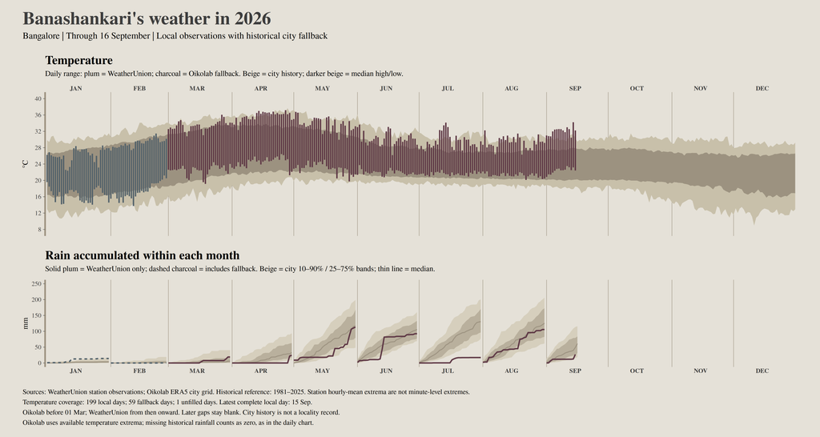

```r
source_colours <- c(
  "WeatherUnion" = weather_palette$actual,
  "Oikolab fallback" = "#52616a",
  "Includes Oikolab fallback" = "#52616a"
)
temp_limits <- range(
  temp_reference$reference_low,
  temp_reference$reference_high,
  daily$low,
  daily$high,
  na.rm = TRUE
)
temp_limits <- c(floor(temp_limits[1] / 4) * 4, ceiling(temp_limits[2] / 4) * 4)
rain_top <- ceiling(max(daily$cumulative, rain_reference$p90, na.rm = TRUE) / 50) * 50
month_breaks <- weather_month_midpoints(chart_year)
x_scale <- function(position = "bottom") {
  scale_x_date(
    limits = c(first_day - 1, last_day + 1),
    breaks = month_breaks$x,
    labels = toupper(month.abb),
    position = position,
    expand = c(0, 0)
  )
}
base_theme <- weather_chart_theme(base_size = 11) +
  theme(
    axis.line.y.right = element_blank(),
    axis.title.y = element_text(size = 10),
    plot.title = element_text(size = 16, face = "bold"),
    plot.subtitle = element_text(size = 10, margin = margin(b = 9)),
    legend.position = "none",
    plot.margin = margin(10, 12, 10, 12)
  )
plots <- list()
for (place in params$localities) {
  daily %>%
    filter(current_locality_name == place) -> d
  ggplot(temp_reference, aes(x = date)) +
    geom_vline(
      xintercept = weather_month_starts(chart_year),
      colour = weather_palette$normal,
      linewidth = 0.25
    ) +
    geom_ribbon(
      aes(ymin = reference_low, ymax = reference_high),
      fill = weather_palette$record
    ) +
    geom_ribbon(
      aes(ymin = normal_low, ymax = normal_high),
      fill = weather_palette$normal
    ) +
    geom_linerange(
      data = filter(d, temp_source != "Missing"),
      aes(ymin = low, ymax = high, colour = temp_source),
      linewidth = 0.85
    ) +
    scale_colour_manual(values = source_colours) +
    x_scale("top") +
    scale_y_continuous(breaks = seq(temp_limits[1], temp_limits[2], 4)) +
    coord_cartesian(ylim = temp_limits) +
    labs(
      title = "Temperature",
      subtitle = "Daily range: plum = WeatherUnion; charcoal = Oikolab fallback. Beige = city history; darker beige = median high/low.",
      x = NULL,
      y = "°C"
    ) +
    base_theme -> temperature_plot
  ggplot(rain_reference, aes(x = date, group = month)) +
    geom_vline(
      xintercept = weather_month_starts(chart_year),
      colour = weather_palette$normal,
      linewidth = 0.25
    ) +
    geom_ribbon(aes(ymin = p10, ymax = p90), fill = weather_palette$band_outer) +
    geom_ribbon(aes(ymin = p25, ymax = p75), fill = weather_palette$band_inner) +
    geom_line(aes(y = median), colour = weather_palette$normal, linewidth = 0.55) +
    geom_line(
      data = d,
      aes(y = cumulative, colour = cumulative_source, linetype = cumulative_source),
      linewidth = 0.85,
      na.rm = TRUE
    ) +
    scale_colour_manual(values = source_colours) +
    scale_linetype_manual(
      values = c("WeatherUnion" = "solid", "Includes Oikolab fallback" = "22", "Missing" = "solid")
    ) +
    x_scale() +
    scale_y_continuous(breaks = seq(0, rain_top, 50)) +
    coord_cartesian(ylim = c(0, rain_top)) +
    labs(
      title = "Rain accumulated within each month",
      subtitle = "Solid plum = WeatherUnion only; dashed charcoal = includes fallback. Beige = city 10–90% / 25–75% bands; thin line = median.",
      x = NULL,
      y = "mm"
    ) +
    base_theme -> rain_plot
  local_days <- sum(d$temp_source == "WeatherUnion")
  fallback_days <- sum(d$temp_source == "Oikolab fallback")
  missing_days <- sum(d$temp_source == "Missing")
  latest_local <- max(d$date[d$temp_source == "WeatherUnion"])
  caption <- paste0(
    "Sources: WeatherUnion station observations; Oikolab ERA5 city grid. Historical reference: 1981–", chart_year - 1,
    ". Station hourly-mean extrema are not minute-level extremes.\n",
    "Temperature coverage: ", local_days, " local days; ", fallback_days, " fallback days; ", missing_days,
    " unfilled days. Latest complete local day: ", format(latest_local, "%d %b"), ".\n",
    "Oikolab before ", format(local_start, "%d %b"), "; WeatherUnion from then onward. Later gaps stay blank. City history is not a locality record.\n",
    "Oikolab uses available temperature extrema; missing historical rainfall counts as zero, as in the daily chart."
  )
  temperature_plot / rain_plot +
    plot_layout(heights = c(1.65, 1)) +
    plot_annotation(
      title = paste0(place, "'s weather in ", chart_year),
      subtitle = paste0("Bangalore | Through ", format(last_complete_day, "%d %B"), " | Local observations with historical city fallback"),
      caption = caption,
      theme = theme(
        plot.background = element_rect(fill = weather_palette$background, colour = NA),
        plot.title = element_text(family = "serif", size = 24, face = "bold", colour = weather_palette$text),
        plot.subtitle = element_text(family = "serif", size = 12, margin = margin(b = 10)),
        plot.caption = element_text(family = "serif", size = 9, hjust = 0, lineheight = 1.25, margin = margin(t = 10)),
        plot.margin = margin(16, 18, 14, 18)
      )
    ) -> p
  plots[[place]] <- p
  ggsave(
    file.path(chart_dir, paste0(tolower(place), "-weather-", chart_year, ".png")),
    p,
    width = 15,
    height = 8.5,
    dpi = 180,
    device = ragg::agg_png,
    bg = weather_palette$background
  )
}
```

Banashankari contributes 199 complete local days from March 1 through September 15, matching the other two selected stations; January and February use the same city fallback.

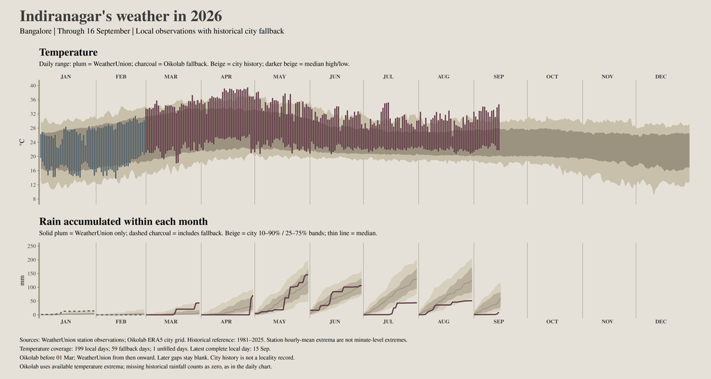

Indiranagar has 199 uninterrupted complete days in the selected March 1–September 15 window. January and February rainfall curves now sum the available ERA5 readings, with missing hours contributing zero as requested, matching the daily chart convention.

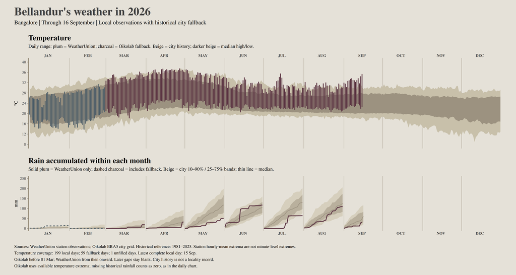

Bellandur also contributes 199 complete local days, the same coverage as Indiranagar. Their local rainfall curves can be compared directly from March onward.

## Checks and verdict

The full date grid preserves absent days, and missing recent values never select ERA5. A 20-hour temperature threshold does not rescue any additional days in this snapshot. Historical rainfall uses the requested zero assumption; unresolved WeatherUnion gaps still stop monthly accumulation. References exclude 2026 and GFS; axes match across localities. Rendered outputs are inspected for source identification, complete units, shared scales, clipping and text overlap. The full-year temperature context is retained as requested; rain reference bands stop at the reporting date.

Insightful: no

These charts establish that the proposed format is feasible for all three selected stations. The common city fallback ends February 28, using available readings and assuming zero rainfall for missing historical hours as requested. They do not yet establish a robust new climate or neighbourhood claim beyond a daily-chart reading, so there is no blog publication or change to the scheduled daily chart job.

Charts:

- `docs/assets/analysis/banashankari-weather-2026.png`
- `docs/assets/analysis/indiranagar-weather-2026.png`
- `docs/assets/analysis/bellandur-weather-2026.png`

Blog post: not published; RSS and homepage unchanged.